# **E-news Express Project**

## Background:

An online news portal aims to expand its business by acquiring new subscribers. Every visitor to the website takes certain actions based on their interest. The company plans to analyze these interests and wants to determine whether a new feature will be effective or not. Companies often analyze users' responses to two variants of a product to decide which of the two variants is more effective. This experimental technique is known as a/b testing that is used to determine whether a new feature attracts users based on a chosen metric.

I am hired as a Data Scientist in E-news Express. The design team of the company has created a new landing page. I have been assigned the task to decide whether the new landing page is more effective to gather new subscribers. 100 users are randomly selected and divided equally into two groups. The old landing page is served to the first group (control group) and the new landing page is served to the second group (treatment group).

## Objective:

Explore the dataset and extract insights from the data. Perform the statistical analysis of business data to answer the following questions:

1. Explore the dataset and extract insights using Exploratory Data Analysis.
2. Do the users spend more time on the new landing page than the old landing page?
3. Is the conversion rate (the proportion of users who visit the landing page and get converted) for the new page greater than the conversion rate for the old page?
4. Does the converted status depend on the preferred language?
5. Is the mean time spent on the new page same for the different language users?

## Data Dictionary:

- user_id - This represents the user ID of the person visiting the website.
- group - This represents whether the user belongs to the first group (control) or the second group (treatment).
- landing_page - This represents whether the landing page is new or old.
- time_spent_on_the_page - This represents the time (in minutes) spent by the user on the landing page.
- converted - This represents whether the user gets converted to a subscriber of the news portal or not.
- language_preferred - This represents the language chosen by the user to view the landing page.

### Import the necessary libraries - pandas, numpy, seaborn, matplotlib.pyplot

```python
# Library to suppress warnings or deprecation notes
import warnings
warnings.filterwarnings('ignore')
```

```python
# import the important packages
import pandas as pd  # library used for data manipulation and analysis
import numpy as np  # library used for working with arrays
import matplotlib.pyplot as plt  # library for plots and visualizations
import seaborn as sns  # library for visualizations

%matplotlib inline

import scipy.stats as stats  # this library contains a large number of probability distributions as well as a growing library of statistical functions
```

### Load the dataset

```python
data = pd.read_csv('abtest.csv')
```

```python
# copying data to another varaible to avoid any changes to original data
df = data.copy()
```

### Check the shape of the dataset

```python
# total number of rows and columns in the file
df.shape
```

```
(100, 6)
```

- The dataset has 100 rows and 6 columns.

### View the first and last few rows of the dataset

```python
# looking at head (5 observations)
df.head()
```

|  | user_id | group | landing_page | time_spent_on_the_page | converted | language_preferred |
| --- | --- | --- | --- | --- | --- | --- |
| 0 | 546592 | control | old | 3.48 | no | Spanish |
| 1 | 546468 | treatment | new | 7.13 | yes | English |
| 2 | 546462 | treatment | new | 4.40 | no | Spanish |
| 3 | 546567 | control | old | 3.02 | no | French |
| 4 | 546459 | treatment | new | 4.75 | yes | Spanish |

```python
# looking at tail (5 observations)
df.tail()
```

|  | user_id | group | landing_page | time_spent_on_the_page | converted | language_preferred |
| --- | --- | --- | --- | --- | --- | --- |
| 95 | 546446 | treatment | new | 5.15 | no | Spanish |
| 96 | 546544 | control | old | 6.52 | yes | English |
| 97 | 546472 | treatment | new | 7.07 | yes | Spanish |
| 98 | 546481 | treatment | new | 6.20 | yes | Spanish |
| 99 | 546483 | treatment | new | 5.86 | yes | English |

### Check the info()

```python
df.info()
```

```
<class 'pandas.core.frame.DataFrame'>
RangeIndex: 100 entries, 0 to 99
Data columns (total 6 columns):
 #   Column                  Non-Null Count  Dtype
---  ------                  --------------  -----
 0   user_id                 100 non-null    int64
 1   group                   100 non-null    object
 2   landing_page            100 non-null    object
 3   time_spent_on_the_page  100 non-null    float64
 4   converted               100 non-null    object
 5   language_preferred      100 non-null    object
dtypes: float64(1), int64(1), object(4)
memory usage: 4.8+ KB
```

**Observations**

- All columns have 100 observations. Hence there are no missing values.
- group, landing_page, converted, language_preferred are object datatype i.e String data type in Python.
- user_id is a Numerical variables of type int.
- time_spent_on_the_page is a float datatype variable.
- user_id - This represents the user ID of the person visiting the website.
- group - This represents whether the user belongs to the first group (control) or the second group (treatment).
- landing_page - This represents whether the landing page is new or old.
- time_spent_on_the_page - This represents the time (in minutes) spent by the user on the landing page.
- converted - This represents whether the user gets converted to a subscriber of the news portal or not.
- language_preferred - This represents the language chosen by the user to view the landing page.
- group, landing_page, converted, language_preferred should be changed to Categorical variables as they have limited set of values.

## Data Preprocessing

### Fixing the datatypes

```python
# categorical column should be converted to categorical type
# (It reduces the data space required to store the dataframe,
# every class in the categorical column will be represented by a number under the hood.
# This is useful during model building)

df['group'] = df.group.astype('category')
df['landing_page'] = df.landing_page.astype('category')
df['converted'] = df.converted.astype('category')
df['language_preferred'] = df.language_preferred.astype('category')
```

```python
df.info()
```

```
<class 'pandas.core.frame.DataFrame'>
RangeIndex: 100 entries, 0 to 99
Data columns (total 6 columns):
 #   Column                  Non-Null Count  Dtype
---  ------                  --------------  -----
 0   user_id                 100 non-null    int64
 1   group                   100 non-null    category
 2   landing_page            100 non-null    category
 3   time_spent_on_the_page  100 non-null    float64
 4   converted               100 non-null    category
 5   language_preferred      100 non-null    category
dtypes: category(4), float64(1), int64(1)
memory usage: 2.6 KB
```

- Now there are 4 categorical columns, 1 integer column and 1 float datatype column.

### Summary of the data

```python
#view some basic statistical details like percentile, mean, std etc.
df.describe().T  # .T is to transpose the rows and columns of the result
```

|  | count | mean | std | min | 25% | 50% | 75% | max |
| --- | --- | --- | --- | --- | --- | --- | --- | --- |
| user_id | 100.0 | 546517.0000 | 52.295779 | 546443.00 | 546467.75 | 546492.500 | 546567.2500 | 546592.00 |
| time_spent_on_the_page | 100.0 | 5.3778 | 2.378166 | 0.19 | 3.88 | 5.415 | 7.0225 | 10.71 |

**Observations**

- The user_id are the IDs of 100 randomly selected users who visited the website. Hence we cannot deduct anything from it's mean, std etc.
- The user_ids start from 546443 and ends in 546592. The mean is 546517 and median is 546492.50.
- time_spent_on_the_page varies from 0.19 mintues to 10.71 minutes for the given users.
- Mean time_spent_on_the_page is 5.3778 minutes and median is 5.415 minutes which are close values.
- There is standard deviation of 2.38 minutes between the time_spent_on_the_page of different users.

### Summary of non-numeric variables

```python
#exclude the numeric variables
df.describe(exclude='number').T
```

|  | count | unique | top | freq |
| --- | --- | --- | --- | --- |
| group | 100 | 2 | control | 50 |
| landing_page | 100 | 2 | new | 50 |
| converted | 100 | 2 | yes | 54 |
| language_preferred | 100 | 3 | French | 34 |

**Let's check the count of each unique category in each of the categorical variables.**

```python
#Making a list of all catrgorical variables
cat_col=['group','landing_page','converted','language_preferred']

#Printing number of count of each unique value in each column
for column in cat_col:
    print(df[column].value_counts())
    print('-'*50)
```

```
control      50
treatment    50
Name: group, dtype: int64
--------------------------------------------------
new    50
old    50
Name: landing_page, dtype: int64
--------------------------------------------------
yes    54
no     46
Name: converted, dtype: int64
--------------------------------------------------
French     34
Spanish    34
English    32
Name: language_preferred, dtype: int64
--------------------------------------------------
```

**Observations**

- There are 2 groups - control and treatment. Each of them have 50 users.
- landing_page has 2 values - new and old. 50 users in the control group have used old landing page and 50 users in the treatment group have used the new landing page.
- converted has 2 values- yes and no. More number of users which is 54 out of 100 were converted as subscriber of the news portal. And the remaining 46 of them did not subscribe to the news portal.
- language_preferred has 3 values - English, French and Spanish.
- 34 out of 100 users prefer French language and another 34 users prefer Spanish language. The remaining 32 users prefer English language.

### Check Missing values

```python
df.isnull().sum()
```

```
user_id                   0
group                     0
landing_page              0
time_spent_on_the_page    0
converted                 0
language_preferred        0
dtype: int64
```

- No Missing Values found

### Check Duplicate values

```python
df.duplicated().sum()
```

```
0
```

- No Duplicate Values found

# EDA

## Univariate Analysis

### Let us explore the numerical variables first

```python
# While doing uni-variate analysis of numerical variables we want to study their central tendency
# and dispersion.
# Let us write a function that will help us create a boxplot, histogram and violinplot for any input numerical
# variable.
# This function takes the numerical column as the input and returns the boxplots,
# boxplot, histogram and violin plots for the variable.

# function to plot a boxplot, histogram and violinplot  along the same scale.


def box_hist_violin(data, figsize=(15, 7), kde=False, bins=None):
    """
    Boxplot, Histogram, Distplot and ViolinPlot combined

    data: dataframe
    feature: dataframe column
    figsize: size of figure (default (15,7))
    kde: whether to show the density curve (default False)
    bins: number of bins for histogram (default None)
    """

    f2, (ax_box2, ax_hist2, ax_violin2) = plt.subplots(
        nrows=3,  # Number of rows of the subplot grid= 3
        sharex=True,  # x-axis will be shared among all subplots
        gridspec_kw={"height_ratios": (1.0, 1.0, 1.0)},
        figsize=figsize,
    )  # creating the 3 subplots



    sns.boxplot( x=data, ax=ax_box2, showmeans=True, color="violet")
    # boxplot will be created and a star will indicate the mean value of the column

    sns.histplot(
        x=data, kde=kde, ax=ax_hist2, bins=bins, palette="winter", color="green"
    ) if bins else sns.histplot(
        x=data, kde=kde, ax=ax_hist2, color="green"
    )  # For histogram
    ax_hist2.axvline( data.mean(), color='g', linestyle="--")  # Add mean to the histogram
    ax_hist2.axvline( data.median(), color='r', linestyle='dashed')  # Add median to the histogram
    ax_hist2.axvline( data.mode()[0], color="black", linestyle='solid')  # Add median to the histogram
    ax_hist2.legend({'Mean':data.mean(),'Median':data.median(),'Mode':data.mode()})

    sns.violinplot(x=data,  ax=ax_violin2, showmeans=True) #violin plot will be created
```

### Univariate Analysis of user_id

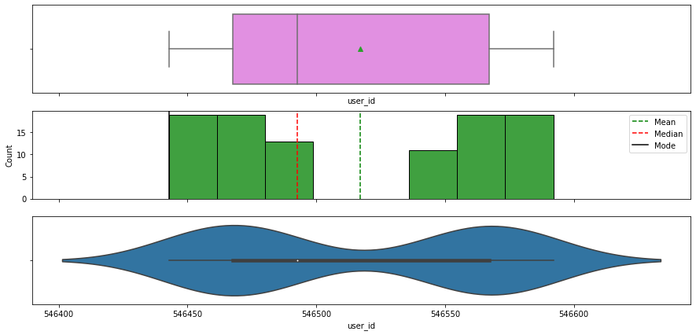

```python
box_hist_violin(df.user_id)
```

**Observations**

- The user_id are the IDs of 100 randomly selected users who visited the website. Hence we cannot deduct anything from it's mean, std etc.
- The user_ids start from 546443 and ends in 546592. The mean is 546517 and median is 546492.50.
- The graph is skewed to the right.

### Univariate Analysis of time_spent_on_the_page

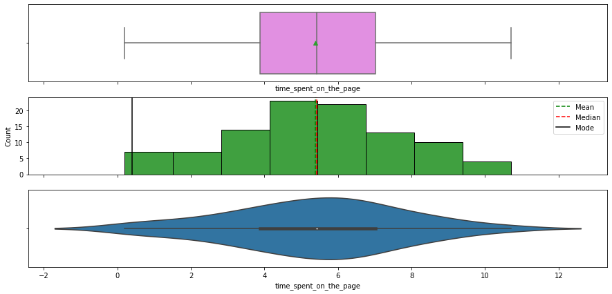

```python
box_hist_violin(df.time_spent_on_the_page)
```

**Observations**

- It is an almost symmetical graph with mean and median having almost equal values of 5.38 and 5.41 minutes respectively.
- Mode is around 0.2 to 0.3 minutes.
- Minimum time spent is 0.19 mintues and maximum is 10.71 minutes.
- Very few users have spent time less than 3 minutes and more than 9 minutes.

### Let us now explore the categorical variables

```python
# function to create labeled barplots


def labeled_barplot(data, feature, perc=False, n=None):
    """
    Barplot with percentage at the top

    data: dataframe
    feature: dataframe column
    perc: whether to display percentages instead of count (default is False)
    n: displays the top n category levels (default is None, i.e., display all levels)
    """

    total = len(data[feature])  # length of the column
    count = data[feature].nunique()
    if n is None:
        plt.figure(figsize=(count + 1, 5))
    else:
        plt.figure(figsize=(n + 1, 5))

    plt.xticks(rotation=90, fontsize=15)
    ax = sns.countplot(
        data=data,
        x=feature,
        palette="Paired",
        order=data[feature].value_counts().index[:n].sort_values(),
    )

    for p in ax.patches:
        if perc == True:
            label = "{:.1f}%".format(
                100 * p.get_height() / total
            )  # percentage of each class of the category
        else:
            label = p.get_height()  # count of each level of the category

        x = p.get_x() + p.get_width() / 2  # width of the plot
        y = p.get_height()  # height of the plot

        ax.annotate(
            label,
            (x, y),
            ha="center",
            va="center",
            size=12,
            xytext=(0, 5),
            textcoords="offset points",
        )  # annotate the percentage

    plt.show()  # show the plot
```

### Univariate Analysis of group

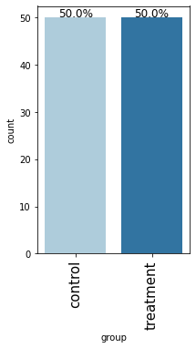

```python
plt.figure(figsize=(10,7))
labeled_barplot(df, 'group', perc=True)
```

**Observations**

- There are 2 groups - control and treatment.
- Each of them have 50 users.

### Univariate Analysis of landing_page

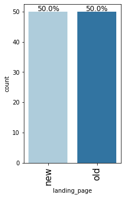

```python
plt.figure(figsize=(10,7))
labeled_barplot(df, 'landing_page', perc=True)
```

**Observations**

- landing_page has 2 values - new and old.
- 50 users have used the old landing page and 50 users have used the new landing page.

### Univariate Analysis of converted

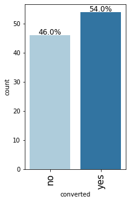

```python
plt.figure(figsize=(10,7))
labeled_barplot(df, 'converted', perc=True)
```

**Observations**

- converted has 2 values- yes and no.
- More number of users which is 54 out of 100 were converted as subscriber of the news portal.
- And the remaining 46 of them did not subscribe to the news portal.

### Univariate Analysis of language_preferred

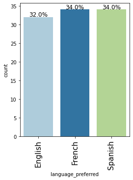

```python
plt.figure(figsize=(10,7))
labeled_barplot(df, 'language_preferred', perc=True)
```

**Observations**

- language_preferred has 3 values - English, French and Spanish.
- 34 out of 100 users prefer French language and another 34 users prefer Spanish language.
- The remaining 32 users prefer English language.

## Bivariate Analysis

**Plot bivariate charts between numeric variables to understand their interaction with each other.**

### Correlation

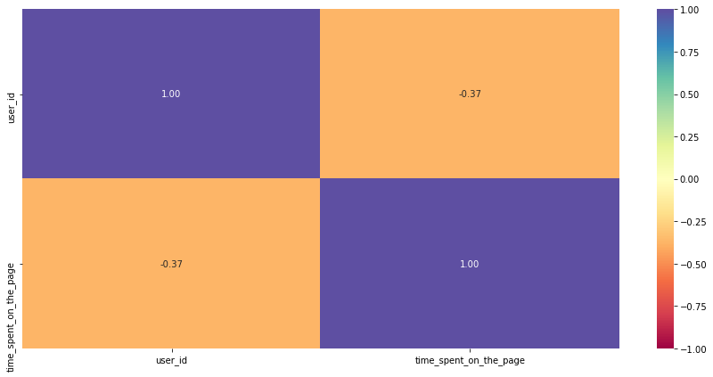

```python
# Check for correlation among numerical variables
num_var = ['user_id','time_spent_on_the_page']

corr = df[num_var].corr()

# plot the heatmap

plt.figure(figsize=(15, 7))
sns.heatmap(corr, annot=True, vmin=-1, vmax=1, fmt=".2f", cmap="Spectral", xticklabels=corr.columns, yticklabels=corr.columns)
plt.show()
```

**Observations**

- From the heat map it seems that user_id and time_spent_on_the_page are exhibiting a weak negative correlation.
- Let us explore more through Scatter Plots.

### Bivariate Scatter Plots

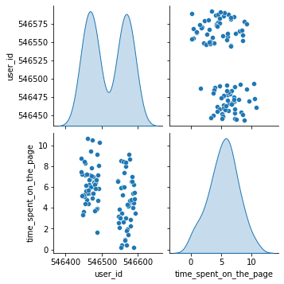

```python
sns.pairplot(data=df[num_var], diag_kind="kde")
plt.show()
```

### Relationship Between Categorical and Numerical variables.

### Relationship of time_spent_on_the_page with Categorical Variables

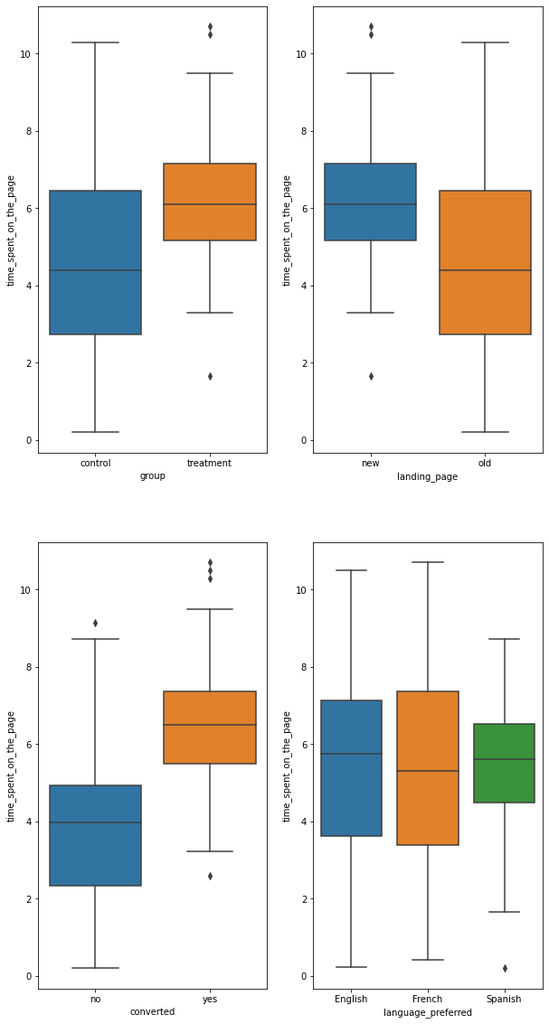

```python
#BiVaraite Analysis for time_spent_on_the_page with Categorical Variables

fig, ax1 =plt.subplots(2,2,figsize=(10, 20))
col_list=['group','landing_page','converted','language_preferred']
for i in range(len(col_list)):
   row=i//2
   col=i%2
   ax=ax1[row,col]

   sns.boxplot(df[col_list[i]],df['time_spent_on_the_page'],ax=ax)
```

### Relationship of group with landing_page

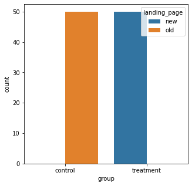

```python
plt.figure(figsize=(5,5))
sns.countplot(data=df,x='group',hue='landing_page')
plt.show()
```

**Observations**

- All the users in Control group are using the old landing page.
- All the users in Treatment group are using the new landing page.

### Relationship of group with converted

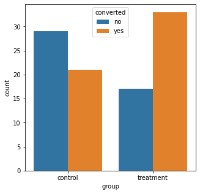

```python
plt.figure(figsize=(5,5))
sns.countplot(data=df,x='group',hue='converted')
plt.show()
```

**Observations**

- In the control group, majority of the users which is around 29 out of 50 did not convert to subscribers.
- In the treatment group, majority of the users which is around 33 out of 50 converted to subscribers.

### Relationship of group with language_preferred

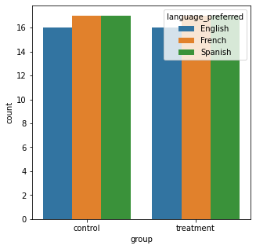

```python
plt.figure(figsize=(5,5))
sns.countplot(data=df,x='group',hue='language_preferred')
plt.show()
```

**Observations**

- The language_prefered follows the same patters across both the groups.
- 16 users in each group prefer English and 17 users in each group prefer French and the remaining 17 prefer Spanish.

### Relationship of converted with language_preferred

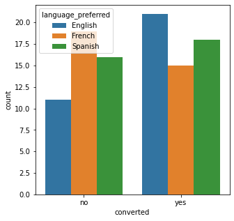

```python
plt.figure(figsize=(5,5))
sns.countplot(data=df,x='converted',hue='language_preferred')
plt.show()
```

## Multivariate Analysis

### Checking the Relation between group, converted, language_preferred and time_spent_on_the_page

```python
# Checking the Average Age across Product,Gender and MaritalStatus
df.groupby(by = ['group','converted','language_preferred'])['time_spent_on_the_page'].mean()
```

```
group      converted  language_preferred
control    no         English               1.776000
                      French                3.669286
                      Spanish               3.688000
           yes        English               5.671818
                      French                7.300000
                      Spanish               6.457143
treatment  no         English               5.506667
                      French                4.400000
                      Spanish               4.660000
           yes        English               7.358000
                      French                6.945000
                      Spanish               6.476364
Name: time_spent_on_the_page, dtype: float64
```

**Observations**

- The highest Average time spent of 7.358 minutes is observed for users with English preferance who are on the treament group and got converted to subscriber.
- The lowest Average time spent of 1.776 minutes is observed for users with English preferance who are on the control group and did not get convert to subscriber.
- Hence, customers who prefer English seem to like the new landing_page more than the old landing_page.

### Checking the Relation between group, converted and time_spent_on_the_page

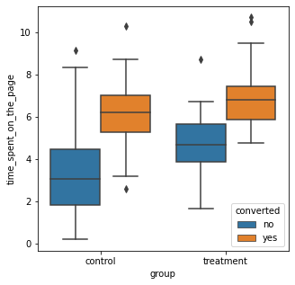

```python
plt.figure(figsize=(5,5))
sns.boxplot(data=df,x='group',y='time_spent_on_the_page',hue='converted')
plt.show()
```

**Observations**

- Users from the treatment group have spent more time on the page than users in the control group.
- In both the groups, users who are converted have spent more time than who were not converted.

### Checking the Relation between group, language_preferred and time_spent_on_the_page

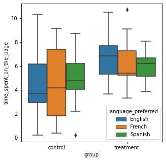

```python
plt.figure(figsize=(5,5))
sns.boxplot(data=df,x='group',y='time_spent_on_the_page',hue='language_preferred')
plt.show()
```

**Observations**

- For all three languages, time spent by users in the treatment group is more than the time spent by them in the control group.

### Checking the Relation between converted, language_preferred and time_spent_on_the_page

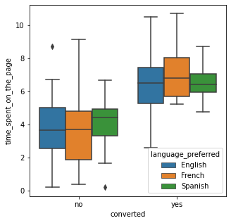

```python
plt.figure(figsize=(5,5))
sns.boxplot(data=df,x='converted',y='time_spent_on_the_page',hue='language_preferred')
plt.show()
```

**Observations**

- Most Users who converted have spent more time on the page than users who did not convert.
- For all three languages, time spent by users who are converted is more than the time spent by those not converted.

# **Conclusion and Recommendations**

## Recommendation to business

# Statistical and Visual Analysis

Now let us answer questions given in the Problem Statement using Statistical and Visual Analysis

## Do the users spend more time on the new landing page than the old landing page?

### Step 1: Define null and alternate hypotheses

H0: The mean time spent on new landing page is equal to the mean time spend on old landing page.

Ha: The mean time spenttime_spent_on_the_page on new landing page is greater than the mean time spend on old landing page.

Let $\mu_1, \mu_2$ be the mean time spent on new landing page and old landing page respectively.

We will test the null hypothesis

> $H_0:\mu_1=\mu_2$

against the alternate hypothesis

> $H_a:\mu_1>\mu_2$

### Step 2: Select Appropriate test

```python
# find the sample means and sample standard deviations for the two samples
print('The mean time spent for new landing page is ' + str(round(df[df['landing_page']=="new"]['time_spent_on_the_page'].mean(),2)))
print('The mean time spent for old landing page is ' + str(round(df[df['landing_page']=="old"]['time_spent_on_the_page'].mean(),2)))
print('The standard deviation of SAT new landing page is ' + str(round(df[df['landing_page']=="new"]['time_spent_on_the_page'].std(), 2)))
print('The standard deviation of SAT old landing page is ' + str(round(df[df['landing_page']=="old"]['time_spent_on_the_page'].std(), 2)))
```

```
The mean time spent for new landing page is 6.22
The mean time spent for old landing page is 4.53
The standard deviation of SAT new landing page is 1.82
The standard deviation of SAT old landing page is 2.58
```

This is a case of a one-tailed test for testing the means from two Samples. Since the standard deviation is known,we choose Two Independent Sample Z-test for Equality of Means. 𝜎1 = 1.82 and 𝜎2 = 2.58

### Visual Analysis

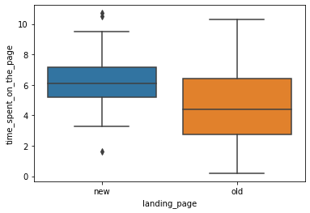

```python
sns.boxplot(data=df,x='landing_page',y='time_spent_on_the_page')
plt.show()
```

### Step 3: Decide the significance level

As given in the problem statement, we select α = 0.05

### Step 4: Calculate the p-value

```python
# user-defined function to compare the equality of two means from two independent populations, where population standard deviations are known
# this function returns the p-value for one tailed test

def ztest_2samp(X1, X2, pop_sd1, pop_sd2, n1, n2):
    '''
    X1 - first of the two independent samples (sample 1)
    X2 - second of the two independent samples (sample 2)
    pop_sd1 - population standard deviation of sample 1
    pop_sd2 - population standard deviation of sample 2
    n1 - size of sample 1
    n2 - size of sample 2
    '''
    from numpy import sqrt, abs # import the required functions
    from scipy.stats import norm # import the required function
    se = sqrt(pop_sd1**2/n1 + pop_sd2**2/n2) # calculate the standard error
    test_stat = ((X1.mean() - X2.mean()) - 0)/ se # calculate the test statistic
    pval = 1 - norm.cdf(abs(test_stat)) # calculate the one-tailed p-value
    return pval # return the p-value
```

```python
# find the p-value using the ztest_2samp() function
p_value = ztest_2samp(df[df['landing_page']=="new"]['time_spent_on_the_page'], df[df['landing_page']=="old"]['time_spent_on_the_page'], 1.82, 2.58, 50 ,50)
print('The P-value is', p_value)
```

```
The P-value is 7.634426865454902e-05
```

### Insight

As the p-value is much less than the level of significance 0.05, we reject the null hypothesis. Thus, we have enough statistical evidence to say that users spend more time on the new landing page as compared to the old landing page.

## Is the conversion rate (the proportion of users who visit the landing page and get converted) for the new page greater than the conversion rate for the old page?

### Step 1: Define null and alternate hypotheses

Let $p_1,p_2$ be the proportions of users who visit the new landing page and old landing page respectively.

We will test the null hypothesis

> $H_0:p_1 =p_2$

against the alternate hypothesis

> $H_a:p_1 > p_2$

### Step 2: Select Appropriate test

As we need to compare the proportions from two independent samples, we use the Two Proportion Z-test.

### Visual Analysis

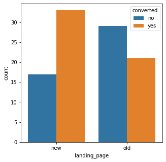

```python
plt.figure(figsize=(5,5))
sns.countplot(data=df,x='landing_page',hue='converted')
plt.show()
```

### Step 3: Decide the significance level

As given in the problem statement, we select α = 0.05

### Step 4: Calculate the p-value

```python
# import the required fuction
from statsmodels.stats.proportion import proportions_ztest

# get the counts of users who got converted
c1=df[(df['landing_page']=="new") & (df['converted']=="yes")]['user_id'].count() #new page
c2=df[(df['landing_page']=="old") & (df['converted']=="yes")]['user_id'].count() #old page

conversions = np.array([c1, c2])

# set the sample sizes
nobs = np.array([50, 50])

# find the p-value
test_stat, p_value = proportions_ztest(conversions, nobs)
print('The p-value is ' + str(p_value))
```

```
The p-value is 0.016052616408112556
```

### Insight

As the p-value is less than the level of significance 0.05, we reject the null hypothesis. Thus, we have enough statistical evidence to say that the conversion rate for the new page is greater than the conversion rate for the old page.

## Does the converted status depend on the preferred language?

### Step 1: Define null and alternate hypotheses

We will test the null hypothesis

> $H_0:$ The converted status is independent of the preferred language

against the alternate hypothesis

> $H_a:$ The converted status depends on the preferred language

### Step 2: Select Appropriate test

As we need to Check whether the categorical variables from a population are independent, we use the Chi-Square Test for Independence.

### Visual Analysis

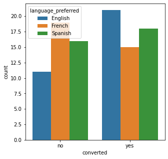

```python
plt.figure(figsize=(5,5))
sns.countplot(data=df,x='converted',hue='language_preferred')
plt.show()
```

### Step 3: Decide the significance level

As given in the problem statement, we select α = 0.05

### Step 4: Calculate the p-value

```python
#import the required functions
from scipy.stats import chi2_contingency
#preparing the contingency table
cont_table= pd.crosstab(df['converted'],df['language_preferred'])
chi, p_value, dof, expected = chi2_contingency(cont_table)
print('The p-value is ', p_value)
```

```
The p-value is  0.21298887487543447
```

### Insight

Since p-value of the test is large, we fail to reject the null hypothesis. Hence we conclude that the converted status is independent of the preferred language.

## Is the mean time spent on the new page same for the different language users?

### Step 1: Define null and alternate hypotheses

Let 𝜇1,𝜇2,𝜇3 be the mean time spent by users on the new page who prefer English, French and Spanish respectively.

We will test the null hypothesis

> $H_0: \mu_1 = \mu_2 = \mu_3$

against the alternative hypothesis

> $H_a: $ At least one mean time is different from the rest.

### Step 2: Select Appropriate test

As there are more than 2 independent samples, we use the One-way ANOVA Test provided normality and equality of variance assumptions are verified.

- For testing of normality, Shapiro-Wilk’s test is applied to the response variable.
- For equality of variance, Levene test is applied to the response variable.

### Step 3: Decide the significance level

As given in the problem statement, we select α = 0.05

```python
#count of users in new page with language_preferred
df[df['landing_page']=="new"]['language_preferred'].value_counts()
```

```
French     17
Spanish    17
English    16
Name: language_preferred, dtype: int64
```

```
language_preferred
English    6.663750
French     6.196471
Spanish    5.835294
Name: time_spent_on_the_page, dtype: float64
```

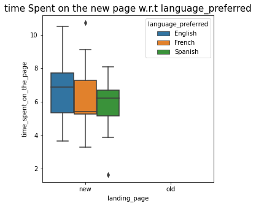

```python
# mean of time_spent_on_the_page on the new page with language_preferred
print(df[df['landing_page']=="new"].groupby("language_preferred")["time_spent_on_the_page"].mean())

# draw the boxplot for visualization
plt.figure(figsize=(5,5))
a=sns.boxplot(data=df[df['landing_page']=="new"],x='landing_page',y='time_spent_on_the_page',hue='language_preferred')
a.set_title("time Spent on the new page w.r.t language_preferred", fontsize=15)
plt.show()
```

Now, the normality and equality of variance assumptions need to be checked.

- For testing of normality, Shapiro-Wilk’s test is applied to the response variable.
- For equality of variance, Levene test is applied to the response variable.

### Shapiro-Wilk’s test

We will test the null hypothesis

> $H_0:$ time_spent_on_the_page follows a normal distribution

against the alternative hypothesis

> $H_a:$ time_spent_on_the_page does not follow a normal distribution

```python
# Assumption 1: Normality
# import the required function
from scipy import stats

# find the p-value
w, p_value = stats.shapiro(df[df['landing_page']=="new"]["time_spent_on_the_page"])
print('The p-value is', p_value)
```

```
The p-value is 0.8040016293525696
```

Since p-value of the test is very large than the 5% significance level, we fail to reject the null hypothesis that the response follows the normal distribution.

### Levene’s test

We will test the null hypothesis

> $H_0$: All the population variances are equal

against the alternative hypothesis

> $H_a$: At least one variance is different from the rest

```python
#Assumption 2: Homogeneity of Variance
#import the required function
from scipy.stats import levene
statistic, p_value = levene( df[df['landing_page']=="new"]["time_spent_on_the_page"][df['language_preferred']=="English"],
                                  df[df['landing_page']=="new"]["time_spent_on_the_page"][df['language_preferred']=="French"],
                                   df[df['landing_page']=="new"]["time_spent_on_the_page"][df['language_preferred']=="Spanish"])
# find the p-value
print('The p-value is', p_value)
```

```
The p-value is 0.46711357711340173
```

Since the p-value is large than the 5% significance level, we fail to reject the null hypothesis of homogeneity of variances.

### Step 4: Calculate the p-value

```python
#import the required function
from scipy.stats import f_oneway

# perform one-way anova test
test_stat, p_value = f_oneway(df[df['landing_page']=="new"].loc[df['language_preferred']=="English",'time_spent_on_the_page'],
                              df[df['landing_page']=="new"].loc[df['language_preferred']=="French",'time_spent_on_the_page'],
                              df[df['landing_page']=="new"].loc[df['language_preferred']=="Spanish",'time_spent_on_the_page'])
print('The p-value is ' + str(p_value))
```

```
The p-value is 0.43204138694325955
```

### Insights

Since the p-value is larger than the 5% significance level, we fail to reject the null hypothesis which says that the mean time spent on the new page is same for the different language users.

## Let's have a quick final overview of the data using the pandas profiling library.

```python
# let us try pandas-profiling now and see how does it simplifies the EDA
# !pip install pandas-profiling==2.8.0
```

```python
pip install pandas-profiling
```

```python
#import pandas_profiling
from pandas_profiling import ProfileReport
# Use the original dataframe, so that original features are considered
prof = ProfileReport(data)
# to view report created by pandas profile
prof
```

[interactive chart not shown]

```python
# to save report obtained via pandas profiling
prof.to_file(output_file='output.html')
```